# Part I - Airlines Delay

## Introduction

This dataset contains scheduled and actual departure and arrival times that were reported by certified U.S. air carriers. In this project, last 10 years data is used for analysis. Original dataset holds at least 1% of the scheduled passenger revenues.

- Description of the dataset can be found in this link: https://www.transtats.bts.gov/DatabaseInfo.asp?QO_VQ=EFD&Yv0x=D
- Dataset can be downloaded from this link: https://dataverse.harvard.edu/dataset.xhtml?persistentId=doi:10.7910/DVN/HG7NV7

# Preliminary Wrangling

```python
# import all packages and set plots to be embedded inline
import numpy as np
import pandas as pd
import matplotlib.pyplot as plt
import seaborn as sb

%matplotlib inline
```

## Load dataset

```python
df=pd.read_csv('Airline_Delay_Cause.csv')
```

## Describe properties

1. Check head of the data
2. Check shape of the data
3. Check data types
4. Check duplicates
5. Check summary statistics

```python
df.head()
```

|  | year | month | carrier | carrier_name | airport | airport_name | arr_flights | arr_del15 | carrier_ct | weather_ct | ... | security_ct | late_aircraft_ct | arr_cancelled | arr_diverted | arr_delay | carrier_delay | weather_delay | nas_delay | security_delay | late_aircraft_delay |
| --- | --- | --- | --- | --- | --- | --- | --- | --- | --- | --- | --- | --- | --- | --- | --- | --- | --- | --- | --- | --- | --- |
| 0 | 2023 | 1 | 9E | Endeavor Air Inc. | ABE | Allentown/Bethlehem/Easton, PA: Lehigh Valley ... | 14.0 | 1.0 | 0.00 | 1.00 | ... | 0.0 | 0.00 | 0.0 | 0.0 | 648.0 | 0.0 | 647.0 | 1.0 | 0.0 | 0.0 |
| 1 | 2023 | 1 | 9E | Endeavor Air Inc. | ABY | Albany, GA: Southwest Georgia Regional | 82.0 | 10.0 | 6.06 | 1.72 | ... | 0.0 | 1.74 | 0.0 | 0.0 | 1800.0 | 1393.0 | 272.0 | 56.0 | 0.0 | 79.0 |
| 2 | 2023 | 1 | 9E | Endeavor Air Inc. | AEX | Alexandria, LA: Alexandria International | 60.0 | 8.0 | 3.54 | 1.59 | ... | 0.0 | 0.16 | 2.0 | 4.0 | 484.0 | 176.0 | 184.0 | 113.0 | 0.0 | 11.0 |
| 3 | 2023 | 1 | 9E | Endeavor Air Inc. | AGS | Augusta, GA: Augusta Regional at Bush Field | 26.0 | 6.0 | 3.40 | 1.20 | ... | 0.0 | 0.76 | 0.0 | 0.0 | 395.0 | 119.0 | 167.0 | 30.0 | 0.0 | 79.0 |
| 4 | 2023 | 1 | 9E | Endeavor Air Inc. | ALB | Albany, NY: Albany International | 109.0 | 30.0 | 8.08 | 0.61 | ... | 0.0 | 11.52 | 3.0 | 0.0 | 1591.0 | 402.0 | 22.0 | 333.0 | 0.0 | 834.0 |

5 rows × 21 columns

```python
df.shape
```

```
(170188, 21)
```

```python
df.info()
```

```
<class 'pandas.core.frame.DataFrame'>
RangeIndex: 170188 entries, 0 to 170187
Data columns (total 21 columns):
 #   Column               Non-Null Count   Dtype
---  ------               --------------   -----
 0   year                 170188 non-null  int64
 1   month                170188 non-null  int64
 2   carrier              170188 non-null  object
 3   carrier_name         170188 non-null  object
 4   airport              170188 non-null  object
 5   airport_name         170188 non-null  object
 6   arr_flights          169954 non-null  float64
 7   arr_del15            169751 non-null  float64
 8   carrier_ct           169954 non-null  float64
 9   weather_ct           169954 non-null  float64
 10  nas_ct               169954 non-null  float64
 11  security_ct          169954 non-null  float64
 12  late_aircraft_ct     169954 non-null  float64
 13  arr_cancelled        169954 non-null  float64
 14  arr_diverted         169954 non-null  float64
 15  arr_delay            169954 non-null  float64
 16  carrier_delay        169954 non-null  float64
 17  weather_delay        169954 non-null  float64
 18  nas_delay            169954 non-null  float64
 19  security_delay       169954 non-null  float64
 20  late_aircraft_delay  169954 non-null  float64
dtypes: float64(15), int64(2), object(4)
memory usage: 27.3+ MB
```

```python
df.isnull().sum()
```

```
year                     0
month                    0
carrier                  0
carrier_name             0
airport                  0
airport_name             0
arr_flights            234
arr_del15              437
carrier_ct             234
weather_ct             234
nas_ct                 234
security_ct            234
late_aircraft_ct       234
arr_cancelled          234
arr_diverted           234
arr_delay              234
carrier_delay          234
weather_delay          234
nas_delay              234
security_delay         234
late_aircraft_delay    234
dtype: int64
```

```python
df.dropna(inplace=True)
```

```python
print(df.duplicated().sum())
df = df.drop_duplicates()
```

```
0
```

```python
df.describe()
```

|  | year | month | arr_flights | arr_del15 | carrier_ct | weather_ct | nas_ct | security_ct | late_aircraft_ct | arr_cancelled | arr_diverted | arr_delay | carrier_delay | weather_delay | nas_delay | security_delay | late_aircraft_delay |
| --- | --- | --- | --- | --- | --- | --- | --- | --- | --- | --- | --- | --- | --- | --- | --- | --- | --- |
| count | 169751.000000 | 169751.000000 | 169751.000000 | 169751.000000 | 169751.000000 | 169751.000000 | 169751.000000 | 169751.000000 | 169751.000000 | 169751.000000 | 169751.000000 | 169751.000000 | 169751.000000 | 169751.000000 | 169751.00000 | 169751.000000 | 169751.000000 |
| mean | 2017.960636 | 6.452869 | 364.525493 | 66.239015 | 20.446550 | 2.223675 | 19.654117 | 0.150337 | 23.764382 | 7.579119 | 0.858393 | 4172.138544 | 1392.834581 | 216.762252 | 929.14285 | 7.000760 | 1626.393842 |
| std | 2.918679 | 3.480293 | 993.980806 | 178.021973 | 48.790948 | 7.161814 | 62.550092 | 0.688842 | 71.801558 | 43.829182 | 3.733346 | 12227.901828 | 3981.384223 | 798.224011 | 3468.12457 | 40.247076 | 5019.990203 |
| min | 2013.000000 | 1.000000 | 1.000000 | 0.000000 | 0.000000 | 0.000000 | 0.000000 | 0.000000 | 0.000000 | 0.000000 | 0.000000 | 0.000000 | 0.000000 | 0.000000 | 0.00000 | 0.000000 | 0.000000 |
| 25% | 2015.000000 | 3.000000 | 51.000000 | 7.000000 | 2.200000 | 0.000000 | 1.040000 | 0.000000 | 1.290000 | 0.000000 | 0.000000 | 339.000000 | 112.000000 | 0.000000 | 37.00000 | 0.000000 | 67.000000 |
| 50% | 2018.000000 | 6.000000 | 103.000000 | 18.000000 | 6.460000 | 0.390000 | 4.010000 | 0.000000 | 5.080000 | 1.000000 | 0.000000 | 1026.000000 | 376.000000 | 18.000000 | 151.00000 | 0.000000 | 325.000000 |
| 75% | 2020.000000 | 9.000000 | 253.000000 | 48.000000 | 17.250000 | 1.840000 | 12.020000 | 0.000000 | 15.460000 | 4.000000 | 1.000000 | 2887.000000 | 1097.000000 | 144.000000 | 486.00000 | 0.000000 | 1073.000000 |
| max | 2023.000000 | 12.000000 | 21977.000000 | 5268.000000 | 1242.160000 | 240.790000 | 2401.790000 | 58.690000 | 1849.000000 | 4951.000000 | 197.000000 | 429194.000000 | 196944.000000 | 31960.000000 | 137443.00000 | 3760.000000 | 158653.000000 |

### What is the structure of your dataset?

> (170188 Rows, 21 Columns)

### What is/are the main feature(s) of interest in your dataset?

> I'm mainly interested in cancelled and delayed flights e.g. how cancelled and delayed flights are distributed, what causes flights to be cancelled or delayed etc.

### What features in the dataset do you think will help support your investigation into your feature(s) of interest?

> arr_flights,arr_delay,weather_delay,nas_delay,carrier_delay,security_delay,late_aircraft_delay

## Univariate Exploration

### Question: number of flights arrived?

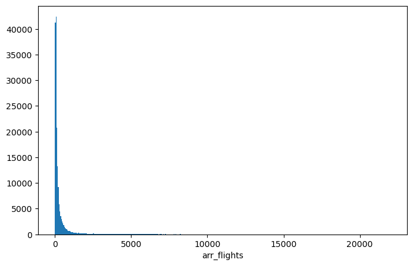

```python
#number of flights arrived
binsize=50
bins = np.arange(0, df['arr_flights'].max()+binsize, binsize)

plt.figure(figsize=[8, 5])
plt.hist(data = df, x = 'arr_flights', bins = bins)
plt.xlabel('arr_flights')
plt.show()
```

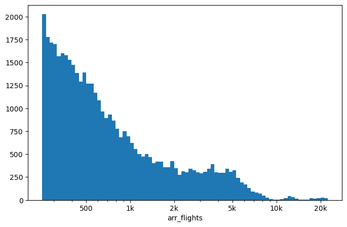

```python
# looks like there's a long tail in the distribution, so let's put it on a log scale instead
log_binsize = 0.025
bins = 10 ** np.arange(2.4, np.log10(df['arr_flights'].max())+log_binsize, log_binsize) #10 ** ...: This part takes each value from the generated array and calculates 10 raised to the power of that value. This effectively transforms the sequence of exponents into a sequence of actual bin edges on a logarithmic scale.

plt.figure(figsize=[8, 5])
plt.hist(data = df, x = 'arr_flights', bins = bins)
plt.xscale('log')
plt.xticks([500, 1e3, 2e3, 5e3, 1e4, 2e4], [500, '1k', '2k', '5k', '10k', '20k'])
plt.xlabel('arr_flights')
plt.show()
```

## Observations

- Plotting original data for `arr_flights` seemed long tailed with most of values towards low values. Used log scale to plot better visualization but it still shows this variable has kind of expontially decreasing toward right kind of distribution.

## Question: arrival delay times?

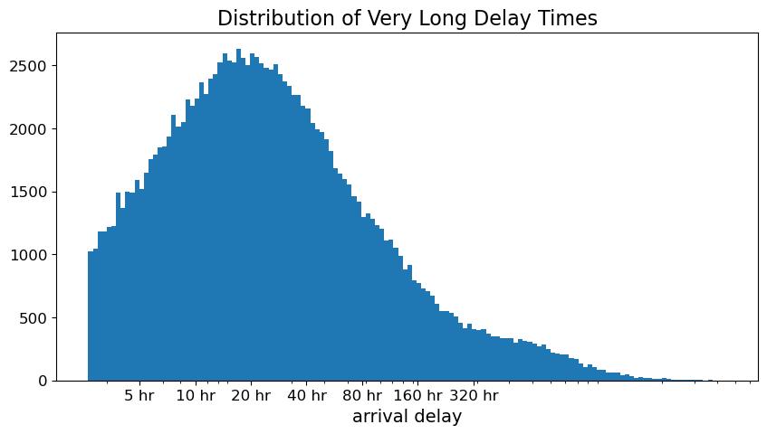

```python
#Arrival delay
#plt.subplot(2,1,2)
log_binsize = 0.025
bins = 10 ** np.arange(2.2, np.log10(df['arr_delay'].max())+log_binsize, log_binsize)
plt.figure(figsize=[10, 5])


plt.hist(data = df, x = 'arr_delay', bins = bins)
plt.xscale('log')
plt.xticks([300, 600, 1200, 2400, 4800, 9600, 19200], ['5 hr', '10 hr', '20 hr', '40 hr', '80 hr', '160 hr', '320 hr'],fontsize=12)
plt.yticks(fontsize=12)
plt.title('Distribution of Very Long Delay Times', fontsize=16)
#plt.title('Distribution of very long delay times',fontsize=16)
plt.xlabel('arrival delay',fontsize=14);
```

## Observations

- Distribution shows that most long arrival delay times were between 10 hrs to 50 hrs

## Question: weather_delay times?

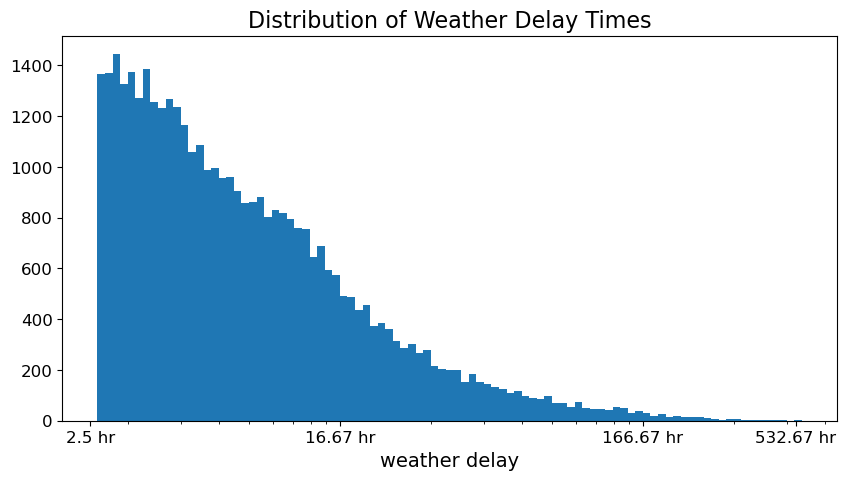

```python
#weather_delay
log_binsize = 0.025
bins = 10 ** np.arange(2.2, np.log10(df['weather_delay'].max())+log_binsize, log_binsize)
plt.figure(figsize=[10, 5])


plt.hist(data = df, x = 'weather_delay', bins = bins)
plt.xscale('log')
plt.xticks([150, 1000, 10000, 31960], ['2.5 hr', '16.67 hr', '166.67 hr', '532.67 hr'], fontsize=12)

plt.yticks(fontsize=12)
plt.title('Distribution of Weather Delay Times', fontsize=16)
#plt.title('Distribution of very long delay times',fontsize=16)
plt.xlabel('weather delay',fontsize=14);
```

## Observations

- Most frequent weather delay times were between 3 hrs to 16 hrs

## Question: Number of flight per Year and Month?

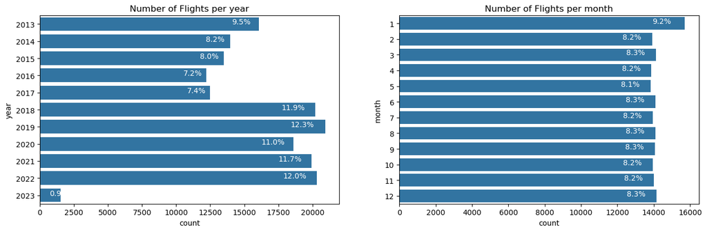

```python
plt.figure(figsize=(16, 12))
plt.subplots_adjust(hspace=0.6)
base_color = sb.color_palette()[0]
n_points = df.shape[0]
for i, j in enumerate(['year', 'month']):
    plt.subplot(2, 2, i+1)
    sb.countplot(data=df, y=j, color=base_color);

    gen_counts = df[j].value_counts()
    locs, labels = plt.yticks() # get the current tick locations and labels
    # loop through each pair of locations and labels
    for loc, label in zip(locs, labels):
        # get the text property for the label to get the correct count
        count = gen_counts[int(label.get_text())]
        pct_string = f'{100*count/n_points:0.1f}%'
        # print the annotation just below the top of the bar
        plt.text(0.92*count, loc, pct_string, ha = 'center', color = 'w')

    plt.title(f'Number of Flights per {j}');
```

## Observations:

- Highest number of flights was in the year of 2019
- Highest number of flights was in the month in the month of January

## Flight delay reasons and how much they contribute to the number of delayed flights

- We also see that the weather is not the main reason for delays. Weather only contributes to 5.20% of the delays.

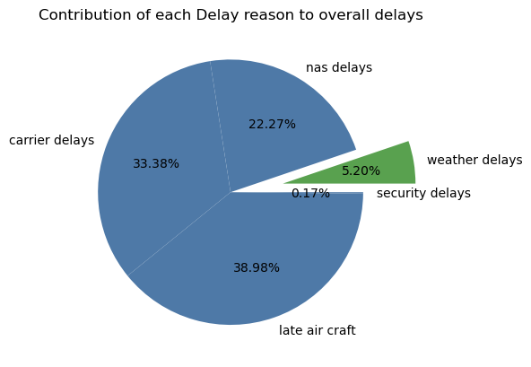

```python
# storing different type of delay sums in variables
wethear_ct_sum= df['weather_delay'].sum()
nas_ct_sum= df['nas_delay'].sum()
carrier_ct_sum= df['carrier_delay'].sum()
security_ct_sum =df['security_delay'].sum()
late_aircraft_sum = df['late_aircraft_delay'].sum()

# total delays
num_of_overall_cancelation = wethear_ct_sum+nas_ct_sum+carrier_ct_sum+security_ct_sum+late_aircraft_sum

# percentage of delays
wethear_ct_sum=(wethear_ct_sum/num_of_overall_cancelation)*100
nas_ct_sum=(nas_ct_sum/num_of_overall_cancelation)*100
carrier_ct_sum=(carrier_ct_sum/num_of_overall_cancelation)*100
security_ct_sum=(security_ct_sum/num_of_overall_cancelation)*100
late_aircraft_sum=(late_aircraft_sum/num_of_overall_cancelation)*100

# plotting to show percentage of delays
X = ['weather delays' , 'nas delays','carrier delays','late air craft','security delays']
Y = [wethear_ct_sum, nas_ct_sum,carrier_ct_sum,late_aircraft_sum,security_ct_sum]
plt.pie(Y, labels=X ,colors=['#59a14f','#4e79a7','#4e79a7','#4e79a7','#4e79a7'], explode=[0.4,0,0,0,0],  autopct='%1.2f%%')
plt.title('Contribution of each Delay reason to overall delays')
plt.show()
```

## Flight cancellation reasons and how much they contribute to the number of canceled flights

- We can clearly see that a late air craft arival is the main reason why flight get canceled and not weather or secuirity problems. Infact weather contributes with only 3.4% and secuirity cancelation contributes with only 0.2%

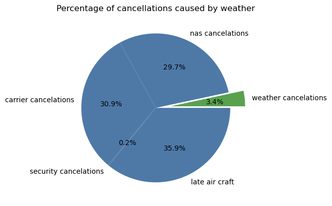

```python
# storing different type of cancellation sums in variables
wethear_ct_sum= df['weather_ct'].sum()
nas_ct_sum= df['nas_ct'].sum()
carrier_ct_sum= df['carrier_ct'].sum()
security_ct_sum =df['security_ct'].sum()
late_aircraft_sum = df['late_aircraft_ct'].sum()

# total cancellations
num_of_overall_cancelation = wethear_ct_sum+nas_ct_sum+carrier_ct_sum+security_ct_sum+late_aircraft_sum

# percentage of cancellations
wethear_ct_sum=(wethear_ct_sum/num_of_overall_cancelation)*100
nas_ct_sum=(nas_ct_sum/num_of_overall_cancelation)*100
carrier_ct_sum=(carrier_ct_sum/num_of_overall_cancelation)*100
security_ct_sum=(security_ct_sum/num_of_overall_cancelation)*100
late_aircraft_sum=(late_aircraft_sum/num_of_overall_cancelation)*100

# plotting to show percentage of cancellations
X = ['weather cancelations','nas cancelations', 'carrier cancelations', 'security cancelations','late air craft']
Y = [wethear_ct_sum,nas_ct_sum,carrier_ct_sum, security_ct_sum,late_aircraft_sum]
plt.pie(Y, labels=X ,colors=['#59a14f','#4e79a7','#4e79a7','#4e79a7','#4e79a7'] , explode=[0.2,0,0,0,0], autopct='%1.1f%%')
plt.title('Percentage of cancellations caused by weather')
plt.show()
```

### Of the features you investigated, were there any unusual distributions? Did you perform any operations on the data to tidy, adjust, or change the form of the data? If so, why did you do this?

- `weather_delay` was converted into hour to show ticks in x-axis for explanation purposes.
- `arr_delay` was converted into hour to show ticks in x-axis for explanation purposes.

## Monthly trends for weather delays

```python
# Function to label the plots
def label_plots(xL,yL,title):
    '''
    This function plots the labels of a figure.

    Args:
    xL : label for x-axis
    yL : label for y-axis
    title: label for title
    '''
    plt.title(title)
    plt.xlabel(xL)
    plt.ylabel(yL)
```

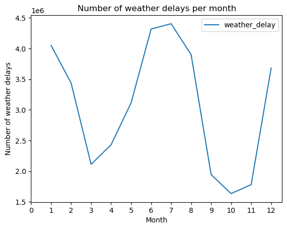

```python
df_weather = df[['month', 'weather_delay']].groupby('month').sum().reset_index()

df_weather.plot(x='month', y='weather_delay' )
#call the function to label the figure
label_plots('Month','Number of weather delays','Number of weather delays per month')
plt.xticks(list(range(0,13,1)))
plt.show()
```

### Observations:

- It demonstrates that weather delays occur in both winter and summer. It demonstrates how hot weather can cause aircraft delays. Flights can be delayed not just by rain and snow, but also by hot temperatures.

## Which city have the most weather delays

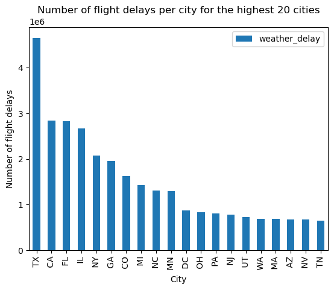

```python
df['city'] = df['airport_name'].str.split(',').str[-1].str.split(':').str[0]
city_delays = df[['city','weather_delay']].groupby('city').sum().reset_index().sort_values('weather_delay',ascending=False)

city_delays = city_delays.iloc[:20]

city_delays.plot.bar(x='city',y='weather_delay')
#call the function to label the figure
label_plots('City','Number of flight delays','Number of flight delays per city for the highest 20 cities')
plt.show()
```

### Observations:

- TX has the highest delays and TN has the lowest delays among top 20 delayed cities.

## Correlation between delays

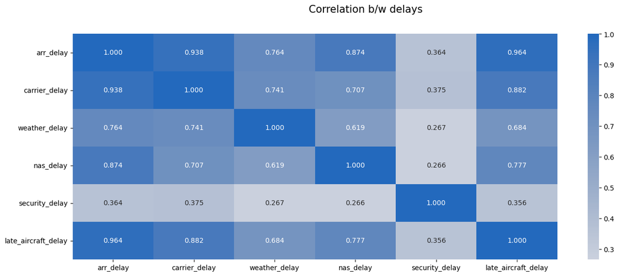

```python
plt.figure(figsize=(16, 6))
sb.heatmap(df[['arr_delay', 'carrier_delay', 'weather_delay', 'nas_delay', 'security_delay', 'late_aircraft_delay']].corr(), annot=True, fmt='.3f', cmap='vlag_r', center=0);
plt.suptitle('Correlation b/w delays', size=15);
```

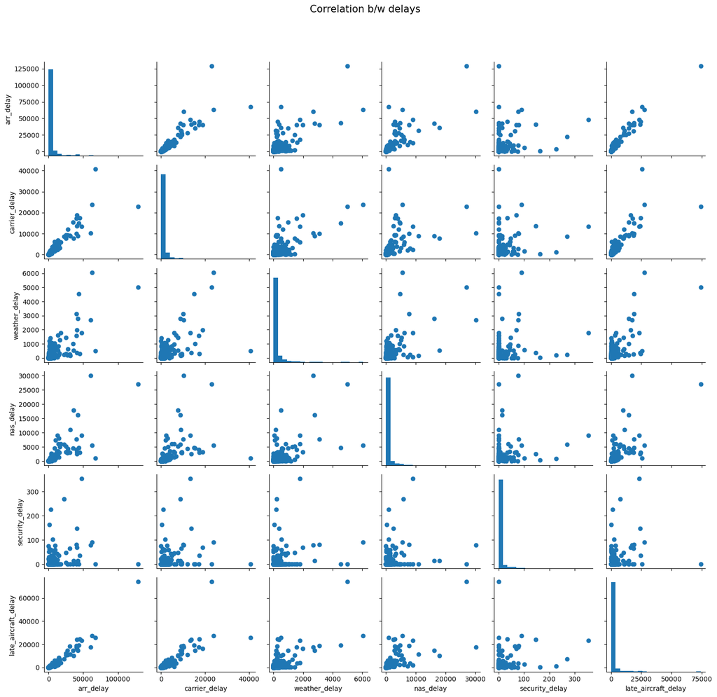

```python
samples = np.random.choice(df.index, 500, replace=False)
flights_samp = df.loc[samples,:]

g = sb.PairGrid(data=flights_samp, vars=['arr_delay', 'carrier_delay', 'weather_delay', 'nas_delay', 'security_delay', 'late_aircraft_delay']);
g = g.map_diag(plt.hist, bins=20);
g.map_offdiag(plt.scatter);
plt.subplots_adjust(top=0.9)
plt.suptitle('Correlation b/w delays', size=15);
```

### Observations:

- `arr_delay` has high positive correlation with `late_aircraft_delay` which is kind of expected since if aircraft is delayed then arrival will be delayed. `carrier_delay` is the second high positively correlated feature with `arr_delay`

## Percentage of flight delays compare to total flights

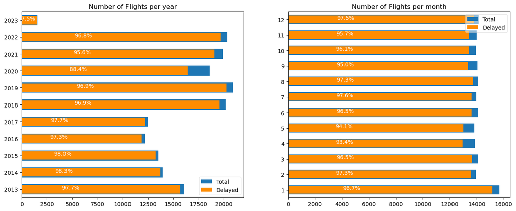

```python
plt.figure(figsize=(16, 16))
plt.subplots_adjust(hspace=0.6)
base_color = sb.color_palette()[0]
n_points = df.shape[0]
for i, j in enumerate(['year', 'month']):
    plt.subplot(2, 2, i+1)

    # get counts of total and delayed flights
    delayed_flights = df[df['arr_delay']>=15]
    gen_counts = df[j].value_counts()
    delayed_gen_counts = delayed_flights[j].value_counts()

    # plot stacked bar charts (reindex or use barplot's order)
    gen_counts.sort_index().plot.barh(label='Total', width=.6)
    delayed_gen_counts.sort_index().plot.barh(label='Delayed', color='darkorange')

    locs, labels = plt.yticks() # get the current tick locations and labels
    # loop through each pair of locations and labels
    for loc, label in zip(locs, labels):
        # get the text property for the label to get the correct count
        count = gen_counts[int(label.get_text())]
        delayed_count = delayed_gen_counts[int(label.get_text())]
        pct_string = f'{100*delayed_count/count:0.1f}%'
        # print the annotation just below the top of the bar
        plt.text(0.30*count, loc, pct_string, ha = 'center', color = 'w')

    plt.legend(framealpha = 0.5, fancybox=True);
    plt.title(f'Number of Flights per {j}');
```

## Total Delays by Airline

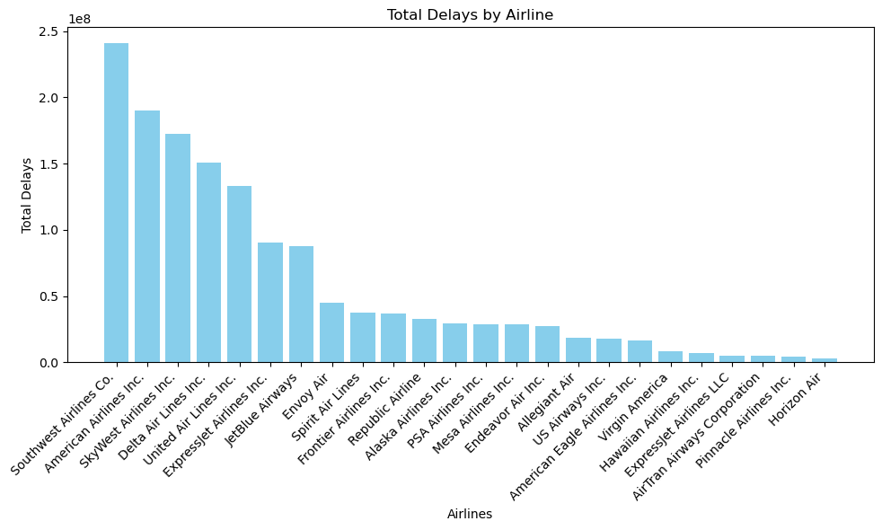

```python
# Calculate the sum of each type of delay for each airline
delay_columns = ['arr_delay', 'carrier_delay', 'weather_delay', 'nas_delay', 'security_delay', 'late_aircraft_delay']
df_delays = df.groupby('carrier_name')[delay_columns].sum()

# Calculate the total delay for each airline
df_delays['total_delay'] = df_delays.sum(axis=1)

# Sort airlines by total delay in descending order
sorted_df = df_delays.sort_values(by='total_delay', ascending=False)

# Create a bar chart
plt.figure(figsize=(10, 6))
plt.bar(sorted_df.index, sorted_df['total_delay'], color='skyblue')

#call the function to label the figure
label_plots('Airlines','Total Delays','Total Delays by Airline')

plt.xticks(rotation=45, ha='right')
plt.tight_layout()

plt.show()
```

### Observations:

- Southwest Airlines Co. had the highest total delayed flights among all airlines

## Distribution of Delays by Airline

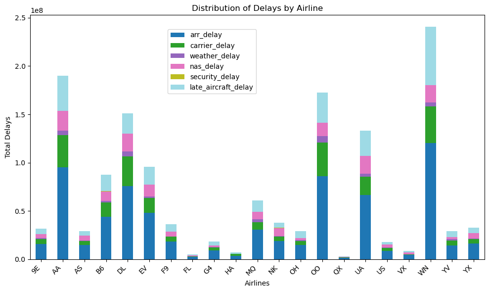

```python
delay_columns = ['arr_delay', 'carrier_delay', 'weather_delay', 'nas_delay', 'security_delay', 'late_aircraft_delay']
df_delays = df.groupby('carrier')[delay_columns].sum()

# Create a stacked bar chart
plt.rcParams["figure.figsize"] = (10,6)
df_delays.plot(kind='bar', stacked=True, colormap='tab20')

# call the function to label figure
label_plots('Airlines','Total Delays','Distribution of Delays by Airline')

plt.xticks(rotation=45, ha='right')
plt.legend(loc='center',bbox_to_anchor=(0.4, 0.81))
plt.tight_layout()

plt.show();
```

### Observations:

- Carrier `WN` had the highest delays among all `carriers` and the distribution showed that `arr_delay` is the most frequent delay types

## Arrival Delay Cause by Airline

```python
# melting columns such that type of delay comes in one column
MELTS_COLUMNS = ['carrier_delay', 'weather_delay', 'nas_delay', 'security_delay', 'late_aircraft_delay']
STAY_COLUMNS = [x for x in df.columns.tolist() if x not in MELTS_COLUMNS]
```

```python
delayed = pd.melt(df, id_vars=STAY_COLUMNS, value_vars=MELTS_COLUMNS, var_name='CauseDelay', value_name='Delay')
delayed = delayed[delayed.Delay>0] # subset with causes delays time > 0 minutes
delayed['CauseDelay'] = delayed['CauseDelay'].str[:-5] # remove the ending 'Delay' from 'Cause' strings
delayed.info()
```

```
<class 'pandas.core.frame.DataFrame'>
Int64Index: 570722 entries, 1 to 848748
Data columns (total 19 columns):
 #   Column            Non-Null Count   Dtype
---  ------            --------------   -----
 0   year              570722 non-null  int64
 1   month             570722 non-null  int64
 2   carrier           570722 non-null  object
 3   carrier_name      570722 non-null  object
 4   airport           570722 non-null  object
 5   airport_name      570722 non-null  object
 6   arr_flights       570722 non-null  float64
 7   arr_del15         570722 non-null  float64
 8   carrier_ct        570722 non-null  float64
 9   weather_ct        570722 non-null  float64
 10  nas_ct            570722 non-null  float64
 11  security_ct       570722 non-null  float64
 12  late_aircraft_ct  570722 non-null  float64
 13  arr_cancelled     570722 non-null  float64
 14  arr_diverted      570722 non-null  float64
 15  arr_delay         570722 non-null  float64
 16  city              570722 non-null  object
 17  CauseDelay        570722 non-null  object
 18  Delay             570722 non-null  float64
dtypes: float64(11), int64(2), object(6)
memory usage: 87.1+ MB
```

```python
categories_cols = ['carrier', 'CauseDelay']

for col in categories_cols:
    delayed[col] = delayed[col].astype('category')

delayed.info()
```

```
<class 'pandas.core.frame.DataFrame'>
Int64Index: 570722 entries, 1 to 848748
Data columns (total 19 columns):
 #   Column            Non-Null Count   Dtype
---  ------            --------------   -----
 0   year              570722 non-null  int64
 1   month             570722 non-null  int64
 2   carrier           570722 non-null  category
 3   carrier_name      570722 non-null  object
 4   airport           570722 non-null  object
 5   airport_name      570722 non-null  object
 6   arr_flights       570722 non-null  float64
 7   arr_del15         570722 non-null  float64
 8   carrier_ct        570722 non-null  float64
 9   weather_ct        570722 non-null  float64
 10  nas_ct            570722 non-null  float64
 11  security_ct       570722 non-null  float64
 12  late_aircraft_ct  570722 non-null  float64
 13  arr_cancelled     570722 non-null  float64
 14  arr_diverted      570722 non-null  float64
 15  arr_delay         570722 non-null  float64
 16  city              570722 non-null  object
 17  CauseDelay        570722 non-null  category
 18  Delay             570722 non-null  float64
dtypes: category(2), float64(11), int64(2), object(4)
memory usage: 79.5+ MB
```

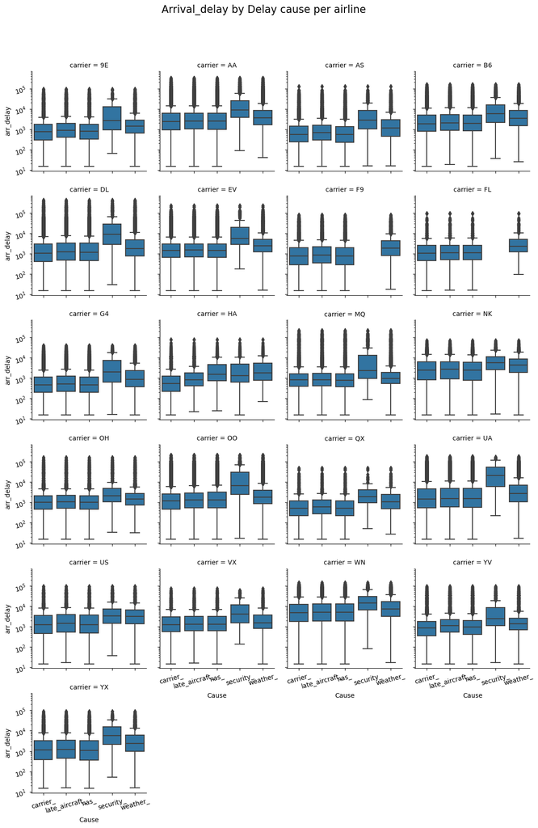

```python
g = sb.FacetGrid(data=delayed, col='carrier', col_wrap=4)
g.map(sb.boxplot, 'CauseDelay', 'arr_delay')
plt.yscale('log');
plt.subplots_adjust(top=0.9)
plt.suptitle('Arrival_delay by Delay cause per airline', size=16);

# set_facet_title()

# # Set axes and tick labels
axes = g.axes.flat

for ax in axes:
    ax.tick_params(rotation=15)
    ax.set_xlabel('Cause')
```

## Observations:

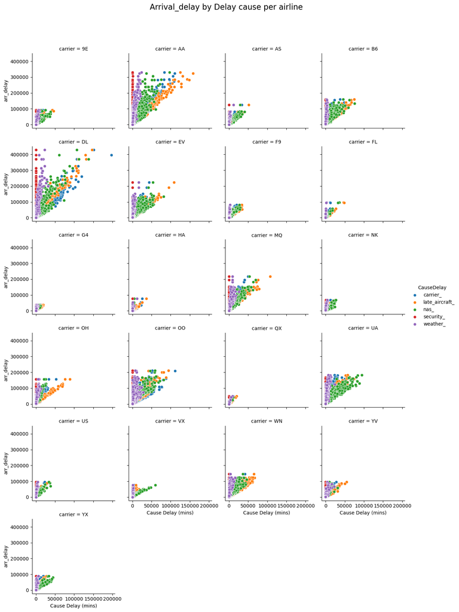

```python
g = sb.FacetGrid(data=delayed, col = 'carrier', col_wrap = 4, hue='CauseDelay')
g.map(sb.scatterplot, 'Delay', 'arr_delay').add_legend()

# Set axes and tick labels
axes = g.axes.flat

for ax in axes:
    ax.set_xlabel('Cause Delay (mins)')

plt.subplots_adjust(top=0.9)
plt.suptitle('Arrival_delay by Delay cause per airline', size=16);
```

## Observations:

- Late Aircraft seems to be the major factor for delays, but it might be biased as some of the data points are overshadowed. But based on the bivariate exploration, Late Aircraft is indeed the major delay factor.
- Most of the curve looks like V-shaped, where the diagonal line (right line of V) represents the positive relationship, and vertical line of V represents no correlation.

### Were there any interesting or surprising interactions between features?

- The majority of the curve in the Arrival delay by delay cause plot is V-shaped, with the diagonal line (right line of V) representing a positive association and the vertical line of V representing a lack of correlation.

## Conclusions

- In this project, airline delays are explored. Data revealed that only 3.4% flights are cancelled due to weather while most of them are cancelled due to `late air craft` (35.9%). Also, contribution of bad weather is only 5.20% to the delay of airlines.Also, flights are delayed due to security has low contribution. `Southwest Airlines Co.` has the most delayed flights among all. Also, correlation value between arrival delay and other features revealed that `late_aircraft_delay` has high positive correlation. Thus, this exploration can play a vital role while investigating the airplane delays and the respective authorities can take necessary actions to increase the efficiency of their service.